# Caret / Recursive Partitioning

Michael Raminski

May 13, 2017

## Exercise 1: caret/logistic regression (5 points)

Rebuild your logistic regression model from the previous week, this time using the `caret` package.

- Calculate the training or apparent performance of the model.
- Calculate an unbiased measure of performance
- Create a ROC Curve for your model

Show all work.

#### Read in Data, add binary variable “delay22”, select only relevant columns, omit all NA values

```r
delays <- read.csv("all.csv")
delays <- tbl_df(delays)
delays$delay22[delays$arr_delay >= 22] <- 0
delays$delay22[delays$arr_delay < 22] <- 1
delays <- select(delays, c(2,4,6,10,15,16,20,22,25,27,45,50))
delaysclean <- na.omit(delays)
delaysclean
```

```
## # A tibble: 284,875 × 12
##    month dep_time dep_delay carrier air_time distance  temp humid
##    <int>    <int>     <int>  <fctr>    <int>    <int> <dbl> <dbl>
## 1      1      554        -6      DL      116      762 39.92 57.33
## 2      1      555        -5      B6      158     1065 39.02 59.37
## 3      1      557        -3      EV       53      229 39.92 57.33
## 4      1      557        -3      B6      140      944 39.02 59.37
## 5      1      558        -2      AA      138      733 39.92 57.33
## 6      1      558        -2      B6      149     1028 39.02 59.37
## 7      1      558        -2      B6      158     1005 39.02 59.37
## 8      1      558        -2      UA      345     2475 39.02 59.37
## 9      1      558        -2      UA      361     2565 39.02 59.37
## 10     1      559        -1      AA      257     1389 39.92 57.33
## # ... with 284,865 more rows, and 4 more variables: wind_gust <dbl>,
## #   pressure <dbl>, lat.y <dbl>, delay22 <dbl>
```

#### Use createDataPartition to split 75% data into training dataset, 25% into test dataset

```r
set.seed(99)
inTraining <- caret::createDataPartition(delaysclean$month, p = .75, list = FALSE)
training <- delaysclean[ inTraining,]
testing  <- delaysclean[-inTraining,]
training
```

```
## # A tibble: 213,658 × 12
##    month dep_time dep_delay carrier air_time distance  temp humid
##    <int>    <int>     <int>  <fctr>    <int>    <int> <dbl> <dbl>
## 1      1      554        -6      DL      116      762 39.92 57.33
## 2      1      555        -5      B6      158     1065 39.02 59.37
## 3      1      557        -3      EV       53      229 39.92 57.33
## 4      1      558        -2      AA      138      733 39.92 57.33
## 5      1      558        -2      B6      158     1005 39.02 59.37
## 6      1      558        -2      UA      361     2565 39.02 59.37
## 7      1      559        -1      AA      257     1389 39.92 57.33
## 8      1      559        -1      UA      337     2227 39.02 59.37
## 9      1      600         0      B6      152     1076 39.92 57.33
## 10     1      600         0      MQ      134      762 39.92 57.33
## # ... with 213,648 more rows, and 4 more variables: wind_gust <dbl>,
## #   pressure <dbl>, lat.y <dbl>, delay22 <dbl>
```

```r
testing
```

```
## # A tibble: 71,217 × 12
##    month dep_time dep_delay carrier air_time distance  temp humid
##    <int>    <int>     <int>  <fctr>    <int>    <int> <dbl> <dbl>
## 1      1      557        -3      B6      140      944 39.02 59.37
## 2      1      558        -2      B6      149     1028 39.02 59.37
## 3      1      558        -2      UA      345     2475 39.02 59.37
## 4      1      602        -3      MQ      105      502 39.92 57.33
## 5      1      606        -4      DL      128      760 39.02 59.37
## 6      1      608         8      MQ      139      719 39.02 59.37
## 7      1      615         0      DL      120      746 39.02 59.37
## 8      1      623        13      AA      153     1096 39.92 57.33
## 9      1      624        -6      MQ      166     1020 39.92 57.33
## 10     1      629        -1      AA      140      733 39.92 57.33
## # ... with 71,207 more rows, and 4 more variables: wind_gust <dbl>,
## #   pressure <dbl>, lat.y <dbl>, delay22 <dbl>
```

#### Calculate Training Model Performance

```r
delaylogistic13 <- glm(formula = delay22 ~ dep_delay + month + air_time + distance + dep_time + humid + temp + lat.y + wind_gust + carrier, family = binomial, data = training)
summary(delaylogistic13)
```

```
##
## Call:
## glm(formula = delay22 ~ dep_delay + month + air_time + distance +
##     dep_time + humid + temp + lat.y + wind_gust + carrier, family = binomial,
##     data = training)
##
## Deviance Residuals:
##     Min       1Q   Median       3Q      Max
## -4.0040   0.0853   0.1653   0.2819   3.0947
##
## Coefficients:
##               Estimate Std. Error  z value Pr(>|z|)
## (Intercept)  6.560e+00  1.097e-01   59.813  < 2e-16 ***
## dep_delay   -1.261e-01  7.177e-04 -175.648  < 2e-16 ***
## month        7.194e-03  2.852e-03    2.522  0.01167 *
## air_time    -1.058e-01  9.177e-04 -115.289  < 2e-16 ***
## distance     1.363e-02  1.215e-04  112.192  < 2e-16 ***
## dep_time    -1.458e-04  2.577e-05   -5.659 1.52e-08 ***
## humid       -8.268e-03  5.911e-04  -13.986  < 2e-16 ***
## temp        -2.725e-02  6.222e-04  -43.789  < 2e-16 ***
## lat.y        3.639e-02  1.888e-03   19.272  < 2e-16 ***
## wind_gust   -9.398e-04  5.418e-04   -1.735  0.08282 .
## carrierAA   -1.284e-01  5.951e-02   -2.158  0.03090 *
## carrierAS    1.227e-01  2.653e-01    0.463  0.64372
## carrierB6   -6.780e-01  5.320e-02  -12.743  < 2e-16 ***
## carrierDL   -3.670e-01  5.514e-02   -6.655 2.82e-11 ***
## carrierEV   -5.273e-01  5.154e-02  -10.230  < 2e-16 ***
## carrierF9   -1.122e+00  1.748e-01   -6.414 1.41e-10 ***
## carrierFL   -1.320e+00  9.195e-02  -14.351  < 2e-16 ***
## carrierHA   -2.407e+00  4.347e-01   -5.538 3.06e-08 ***
## carrierMQ   -1.122e+00  5.637e-02  -19.911  < 2e-16 ***
## carrierOO   -1.052e+00  1.229e+00   -0.856  0.39214
## carrierUA   -1.525e-01  5.422e-02   -2.812  0.00492 **
## carrierUS   -1.006e+00  6.114e-02  -16.446  < 2e-16 ***
## carrierVX    1.041e-01  1.005e-01    1.037  0.29994
## carrierWN    2.938e-01  6.851e-02    4.288 1.80e-05 ***
## carrierYV   -5.766e-01  2.452e-01   -2.352  0.01869 *
## ---
## Signif. codes:  0 '***' 0.001 '**' 0.01 '*' 0.05 '.' 0.1 ' ' 1
##
## (Dispersion parameter for binomial family taken to be 1)
##
##     Null deviance: 203579  on 213657  degrees of freedom
## Residual deviance:  74692  on 213633  degrees of freedom
## AIC: 74742
##
## Number of Fisher Scoring iterations: 7
```

```r
prob <- predict(delaylogistic13, training, type="response")
logit.pred <- factor(prob>.5, levels=c(FALSE,TRUE), labels=c(0,1))
logit.pref <- table(training$delay22, logit.pred, dnn=c("Actual", "Predicted"))
logit.pref
```

```
##       Predicted
## Actual      0      1
##      0  29292   9879
##      1   3399 171088
```

```r
training$logit[logit.pred == 0] <- 0
training$logit[logit.pred == 1] <- 1

ConfMatrix <- caret::confusionMatrix(training$logit, training$delay22)
ConfMatrix
```

```
## Confusion Matrix and Statistics
##
##           Reference
## Prediction      0      1
##          0  29292   3399
##          1   9879 171088
##
##                Accuracy : 0.9379
##                  95% CI : (0.9368, 0.9389)
##     No Information Rate : 0.8167
##     P-Value [Acc > NIR] : < 2.2e-16
##
##                   Kappa : 0.7782
##  Mcnemar's Test P-Value : < 2.2e-16
##
##             Sensitivity : 0.7478
##             Specificity : 0.9805
##          Pos Pred Value : 0.8960
##          Neg Pred Value : 0.9454
##              Prevalence : 0.1833
##          Detection Rate : 0.1371
##    Detection Prevalence : 0.1530
##       Balanced Accuracy : 0.8642
##
##        'Positive' Class : 0
##
```

#### Calculate Unbiased Measure of Performance - fit model to test dataset

```r
delaylogistic14 <- glm(formula = delay22 ~ dep_delay + month + air_time + distance + dep_time + humid + temp + lat.y + wind_gust + carrier, family = binomial, data = testing)
summary(delaylogistic14)
```

```
##
## Call:
## glm(formula = delay22 ~ dep_delay + month + air_time + distance +
##     dep_time + humid + temp + lat.y + wind_gust + carrier, family = binomial,
##     data = testing)
##
## Deviance Residuals:
##     Min       1Q   Median       3Q      Max
## -3.9150   0.0864   0.1653   0.2797   3.0121
##
## Coefficients:
##               Estimate Std. Error  z value Pr(>|z|)
## (Intercept)  6.864e+00  1.911e-01   35.910  < 2e-16 ***
## dep_delay   -1.256e-01  1.236e-03 -101.562  < 2e-16 ***
## month        4.857e-03  4.933e-03    0.984  0.32489
## air_time    -1.048e-01  1.571e-03  -66.744  < 2e-16 ***
## distance     1.350e-02  2.079e-04   64.946  < 2e-16 ***
## dep_time    -1.975e-04  4.492e-05   -4.396 1.10e-05 ***
## humid       -9.955e-03  1.033e-03   -9.641  < 2e-16 ***
## temp        -2.535e-02  1.079e-03  -23.483  < 2e-16 ***
## lat.y        3.094e-02  3.267e-03    9.471  < 2e-16 ***
## wind_gust   -1.929e-03  6.898e-04   -2.797  0.00516 **
## carrierAA   -2.210e-01  1.043e-01   -2.118  0.03417 *
## carrierAS    1.344e-01  5.082e-01    0.264  0.79149
## carrierB6   -7.788e-01  9.354e-02   -8.325  < 2e-16 ***
## carrierDL   -3.893e-01  9.727e-02   -4.002 6.27e-05 ***
## carrierEV   -5.823e-01  9.058e-02   -6.429 1.28e-10 ***
## carrierF9   -1.252e+00  2.881e-01   -4.344 1.40e-05 ***
## carrierFL   -1.349e+00  1.622e-01   -8.313  < 2e-16 ***
## carrierHA   -3.627e+00  5.619e-01   -6.454 1.09e-10 ***
## carrierMQ   -1.077e+00  9.879e-02  -10.903  < 2e-16 ***
## carrierOO   -9.654e-01  1.663e+00   -0.581  0.56155
## carrierUA   -2.348e-01  9.496e-02   -2.473  0.01342 *
## carrierUS   -9.616e-01  1.081e-01   -8.896  < 2e-16 ***
## carrierVX    4.060e-02  1.723e-01    0.236  0.81368
## carrierWN    3.861e-01  1.219e-01    3.168  0.00154 **
## carrierYV   -8.237e-01  4.233e-01   -1.946  0.05167 .
## ---
## Signif. codes:  0 '***' 0.001 '**' 0.01 '*' 0.05 '.' 0.1 ' ' 1
##
## (Dispersion parameter for binomial family taken to be 1)
##
##     Null deviance: 67793  on 71216  degrees of freedom
## Residual deviance: 24763  on 71192  degrees of freedom
## AIC: 24813
##
## Number of Fisher Scoring iterations: 7
```

```r
prob2 <- predict(delaylogistic14, testing, type="response")
logit.pred2 <- factor(prob2>.5, levels=c(FALSE,TRUE), labels=c(0,1))
logit.pref2 <- table(testing$delay22, logit.pred2, dnn=c("Actual", "Predicted"))
logit.pref2
```

```
##       Predicted
## Actual     0     1
##      0  9797  3238
##      1  1144 57038
```

```r
testing$logit[logit.pred2 == 0] <- 0
testing$logit[logit.pred2 == 1] <- 1

ConfMatrix2 <- caret::confusionMatrix(testing$logit, testing$delay22)
ConfMatrix2
```

```
## Confusion Matrix and Statistics
##
##           Reference
## Prediction     0     1
##          0  9797  1144
##          1  3238 57038
##
##                Accuracy : 0.9385
##                  95% CI : (0.9367, 0.9402)
##     No Information Rate : 0.817
##     P-Value [Acc > NIR] : < 2.2e-16
##
##                   Kappa : 0.7806
##  Mcnemar's Test P-Value : < 2.2e-16
##
##             Sensitivity : 0.7516
##             Specificity : 0.9803
##          Pos Pred Value : 0.8954
##          Neg Pred Value : 0.9463
##              Prevalence : 0.1830
##          Detection Rate : 0.1376
##    Detection Prevalence : 0.1536
##       Balanced Accuracy : 0.8660
##
##        'Positive' Class : 0
##
```

#### Fit model to entire dataset

```r
delaylogistic15 <- glm(formula = delay22 ~ dep_delay + month + air_time + distance + dep_time + humid + temp + lat.y + wind_gust + carrier, family = binomial, data = delaysclean)
summary(delaylogistic15)
```

```
##
## Call:
## glm(formula = delay22 ~ dep_delay + month + air_time + distance +
##     dep_time + humid + temp + lat.y + wind_gust + carrier, family = binomial,
##     data = delaysclean)
##
## Deviance Residuals:
##     Min       1Q   Median       3Q      Max
## -4.0060   0.0856   0.1654   0.2813   3.1009
##
## Coefficients:
##               Estimate Std. Error  z value Pr(>|z|)
## (Intercept)  6.638e+00  9.512e-02   69.784  < 2e-16 ***
## dep_delay   -1.259e-01  6.205e-04 -202.927  < 2e-16 ***
## month        6.581e-03  2.469e-03    2.665 0.007688 **
## air_time    -1.055e-01  7.922e-04 -133.216  < 2e-16 ***
## distance     1.360e-02  1.049e-04  129.636  < 2e-16 ***
## dep_time    -1.585e-04  2.235e-05   -7.092 1.32e-12 ***
## humid       -8.688e-03  5.129e-04  -16.938  < 2e-16 ***
## temp        -2.677e-02  5.390e-04  -49.672  < 2e-16 ***
## lat.y        3.498e-02  1.634e-03   21.404  < 2e-16 ***
## wind_gust   -1.270e-03  4.444e-04   -2.857 0.004280 **
## carrierAA   -1.522e-01  5.168e-02   -2.945 0.003229 **
## carrierAS    1.251e-01  2.353e-01    0.532 0.595065
## carrierB6   -7.036e-01  4.624e-02  -15.216  < 2e-16 ***
## carrierDL   -3.729e-01  4.796e-02   -7.774 7.63e-15 ***
## carrierEV   -5.414e-01  4.479e-02  -12.087  < 2e-16 ***
## carrierF9   -1.158e+00  1.494e-01   -7.749 9.24e-15 ***
## carrierFL   -1.327e+00  7.999e-02  -16.590  < 2e-16 ***
## carrierHA   -2.797e+00  3.426e-01   -8.163 3.26e-16 ***
## carrierMQ   -1.111e+00  4.895e-02  -22.687  < 2e-16 ***
## carrierOO   -1.019e+00  9.887e-01   -1.031 0.302749
## carrierUA   -1.737e-01  4.708e-02   -3.691 0.000224 ***
## carrierUS   -9.952e-01  5.321e-02  -18.703  < 2e-16 ***
## carrierVX    8.791e-02  8.676e-02    1.013 0.310931
## carrierWN    3.153e-01  5.971e-02    5.281 1.28e-07 ***
## carrierYV   -6.371e-01  2.124e-01   -2.999 0.002707 **
## ---
## Signif. codes:  0 '***' 0.001 '**' 0.01 '*' 0.05 '.' 0.1 ' ' 1
##
## (Dispersion parameter for binomial family taken to be 1)
##
##     Null deviance: 271372  on 284874  degrees of freedom
## Residual deviance:  99471  on 284850  degrees of freedom
## AIC: 99521
##
## Number of Fisher Scoring iterations: 7
```

```r
prob3 <- predict(delaylogistic15, delaysclean, type="response")
logit.pred3 <- factor(prob3>.5, levels=c(FALSE,TRUE), labels=c(0,1))
logit.pref3 <- table(delaysclean$delay22, logit.pred3, dnn=c("Actual", "Predicted"))
logit.pref3
```

```
##       Predicted
## Actual      0      1
##      0  39086  13120
##      1   4541 228128
```

```r
delaysclean$logit[logit.pred3 == 0] <- 0
delaysclean$logit[logit.pred3 == 1] <- 1

ConfMatrix3 <- caret::confusionMatrix(delaysclean$logit, delaysclean$delay22)
ConfMatrix3
```

```
## Confusion Matrix and Statistics
##
##           Reference
## Prediction      0      1
##          0  39086   4541
##          1  13120 228128
##
##                Accuracy : 0.938
##                  95% CI : (0.9371, 0.9389)
##     No Information Rate : 0.8167
##     P-Value [Acc > NIR] : < 2.2e-16
##
##                   Kappa : 0.7788
##  Mcnemar's Test P-Value : < 2.2e-16
##
##             Sensitivity : 0.7487
##             Specificity : 0.9805
##          Pos Pred Value : 0.8959
##          Neg Pred Value : 0.9456
##              Prevalence : 0.1833
##          Detection Rate : 0.1372
##    Detection Prevalence : 0.1531
##       Balanced Accuracy : 0.8646
##
##        'Positive' Class : 0
##
```

#### Create ROC Curve

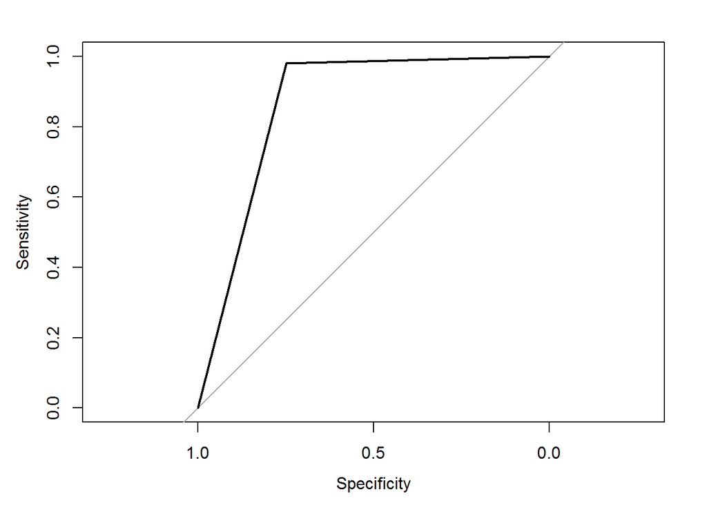

```r
ROCcurve <- roc(response = delaysclean$delay22, predictor = delaysclean$logit)
plot(ROCcurve)
```

```r
auc(ROCcurve)
```

```
## Area under the curve: 0.8646
```

## Exercise 2: caret/rpart (5 points)

Using the `caret` and `rpart` packages, create a **classification** model for flight delays using your NYC FLight data. Your solution should include:

- The use of `caret` and `rpart` to train a model.
- An articulation of the the problem your are
- An naive model
- An unbiased calculation of the performance metric
- A plot of your model – (the actual tree; there are several ways to do this)
- A discussion of your model

Show and describe all work

#### Problem to be Solved

By experimenting with decision trees, we can find the predictor variables that best split the data. This can show important patterns in the data and potentially lead to classifying new variables that could produce a more predictive model.

#### Naive Model

```r
delay0 <- summarise(filter(delaysclean, dep_delay >= 0), Delay0 = sum(delay22 == 0)/sum(delay22 >= 0))
delay5 <- summarise(filter(delaysclean, dep_delay >= 5), Delay5 = sum(delay22 == 0)/sum(delay22 >= 0))
delay10 <- summarise(filter(delaysclean, dep_delay >= 10), Delay10 = sum(delay22 == 0)/sum(delay22 >= 0))
delay15 <- summarise(filter(delaysclean, dep_delay >= 15), Delay15 = sum(delay22 == 0)/sum(delay22 >= 0))
delay20 <- summarise(filter(delaysclean, dep_delay >= 20), Delay20 = sum(delay22 == 0)/sum(delay22 >= 0))
delay25 <- summarise(filter(delaysclean, dep_delay >= 25), Delay25 = sum(delay22 == 0)/sum(delay22 >= 0))
delay30 <- summarise(filter(delaysclean, dep_delay >= 30), Delay30 = sum(delay22 == 0)/sum(delay22 >= 0))
delay35 <- summarise(filter(delaysclean, dep_delay >= 35), Delay35 = sum(delay22 == 0)/sum(delay22 >= 0))
delay40 <- summarise(filter(delaysclean, dep_delay >= 40), Delay40 = sum(delay22 == 0)/sum(delay22 >= 0))
delay45 <- summarise(filter(delaysclean, dep_delay >= 45), Delay45 = sum(delay22 == 0)/sum(delay22 >= 0))
delay50 <- summarise(filter(delaysclean, dep_delay >= 50), Delay50 = sum(delay22 == 0)/sum(delay22 >= 0))

Delay22Perc <- data.frame(delay0, delay5, delay10, delay15, delay20, delay25, delay30, delay35, delay40, delay45, delay50)
Delay22Perc
```

```
##      Delay0    Delay5   Delay10   Delay15   Delay20   Delay25   Delay30
## 1 0.3897471 0.5248109 0.6195351 0.7047345 0.7798169 0.8454268 0.8966994
##     Delay35  Delay40   Delay45   Delay50
## 1 0.9353341 0.961468 0.9773256 0.9868052
```

#### Calculate Training Model Performance

```r
dtree <- rpart(delay22 ~ dep_delay + month + air_time + distance + dep_time + humid + temp + lat.y + wind_gust + carrier, data = training, method="class",
               parms=list(split="information"))
print(dtree)
```

```
## n= 213658
##
## node), split, n, loss, yval, (yprob)
##       * denotes terminal node
##
## 1) root 213658 39171 1 (0.18333505 0.81666495)
##   2) dep_delay>=25.5 32277  4584 0 (0.85797937 0.14202063) *
##   3) dep_delay< 25.5 181381 11478 1 (0.06328116 0.93671884) *
```

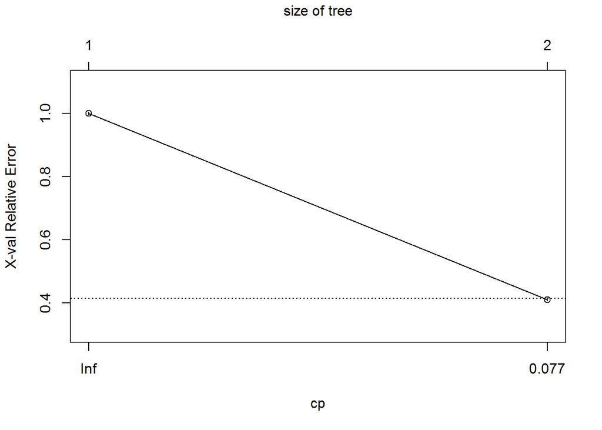

```r
plotcp(dtree)
```

```r
dtree.pred <- predict(dtree, training, type="class")

training$logit2[dtree.pred == 0] <- 0
training$logit2[dtree.pred == 1] <- 1

ConfMatrix4 <- caret::confusionMatrix(training$logit2, training$delay22)
ConfMatrix4
```

```
## Confusion Matrix and Statistics
##
##           Reference
## Prediction      0      1
##          0  27693   4584
##          1  11478 169903
##
##                Accuracy : 0.9248
##                  95% CI : (0.9237, 0.9259)
##     No Information Rate : 0.8167
##     P-Value [Acc > NIR] : < 2.2e-16
##
##                   Kappa : 0.7306
##  Mcnemar's Test P-Value : < 2.2e-16
##
##             Sensitivity : 0.7070
##             Specificity : 0.9737
##          Pos Pred Value : 0.8580
##          Neg Pred Value : 0.9367
##              Prevalence : 0.1833
##          Detection Rate : 0.1296
##    Detection Prevalence : 0.1511
##       Balanced Accuracy : 0.8404
##
##        'Positive' Class : 0
##
```

#### Calculate Unbiased Measure of Performance

```r
dtree2 <- rpart(delay22 ~ dep_delay + month + air_time + distance + dep_time + humid + temp + lat.y + wind_gust + carrier, data = testing, method="class",
               parms=list(split="information"))
print(dtree2)
```

```
## n= 71217
##
## node), split, n, loss, yval, (yprob)
##       * denotes terminal node
##
## 1) root 71217 13035 1 (0.18303214 0.81696786)
##   2) dep_delay>=24.5 11109  1747 0 (0.84274012 0.15725988) *
##   3) dep_delay< 24.5 60108  3673 1 (0.06110667 0.93889333) *
```

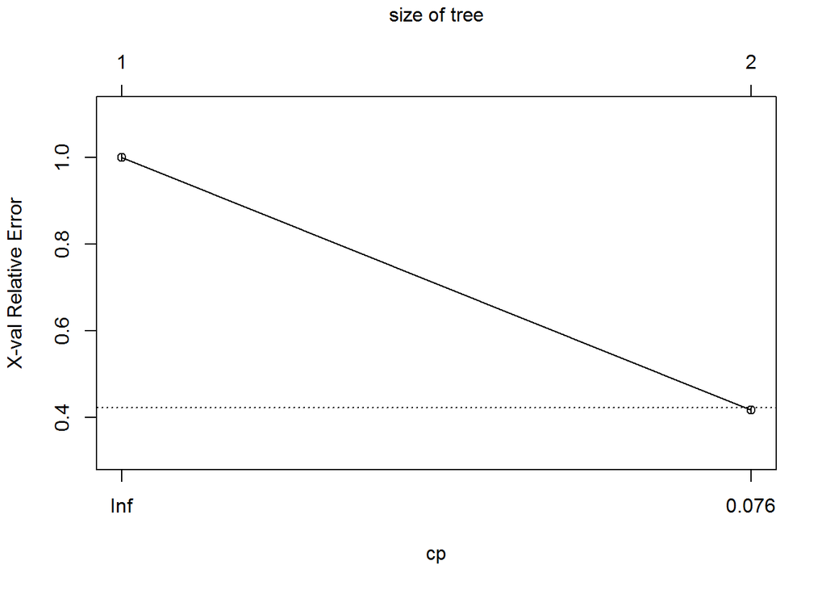

```r
plotcp(dtree2)
```

```r
dtree.pred2 <- predict(dtree2, testing, type="class")

testing$logit2[dtree.pred2 == 0] <- 0
testing$logit2[dtree.pred2 == 1] <- 1

ConfMatrix5 <- caret::confusionMatrix(testing$logit2, testing$delay22)
ConfMatrix5
```

```
## Confusion Matrix and Statistics
##
##           Reference
## Prediction     0     1
##          0  9362  1747
##          1  3673 56435
##
##                Accuracy : 0.9239
##                  95% CI : (0.9219, 0.9258)
##     No Information Rate : 0.817
##     P-Value [Acc > NIR] : < 2.2e-16
##
##                   Kappa : 0.73
##  Mcnemar's Test P-Value : < 2.2e-16
##
##             Sensitivity : 0.7182
##             Specificity : 0.9700
##          Pos Pred Value : 0.8427
##          Neg Pred Value : 0.9389
##              Prevalence : 0.1830
##          Detection Rate : 0.1315
##    Detection Prevalence : 0.1560
##       Balanced Accuracy : 0.8441
##
##        'Positive' Class : 0
##
```

#### Fit model to entire dataset

```r
dtree3 <- rpart(delay22 ~ dep_delay + month + air_time + distance + dep_time + humid + temp + lat.y + wind_gust + carrier, data = delaysclean, method="class",
               parms=list(split="information"))
print(dtree3)
```

```
## n= 284875
##
## node), split, n, loss, yval, (yprob)
##       * denotes terminal node
##
## 1) root 284875 52206 1 (0.18325932 0.81674068)
##   2) dep_delay>=25.5 43098  6164 0 (0.85697712 0.14302288) *
##   3) dep_delay< 25.5 241777 15272 1 (0.06316564 0.93683436) *
```

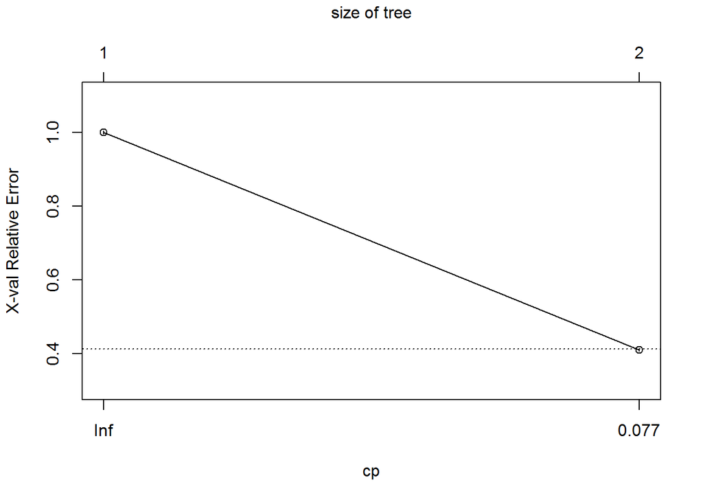

```r
plotcp(dtree3)
```

```r
dtree.pred3 <- predict(dtree3, delaysclean, type="class")

delaysclean$logit2[dtree.pred3 == 0] <- 0
delaysclean$logit2[dtree.pred3 == 1] <- 1

ConfMatrix6 <- caret::confusionMatrix(delaysclean$logit2, delaysclean$delay22)
ConfMatrix6
```

```
## Confusion Matrix and Statistics
##
##           Reference
## Prediction      0      1
##          0  36934   6164
##          1  15272 226505
##
##                Accuracy : 0.9248
##                  95% CI : (0.9238, 0.9257)
##     No Information Rate : 0.8167
##     P-Value [Acc > NIR] : < 2.2e-16
##
##                   Kappa : 0.7304
##  Mcnemar's Test P-Value : < 2.2e-16
##
##             Sensitivity : 0.7075
##             Specificity : 0.9735
##          Pos Pred Value : 0.8570
##          Neg Pred Value : 0.9368
##              Prevalence : 0.1833
##          Detection Rate : 0.1296
##    Detection Prevalence : 0.1513
##       Balanced Accuracy : 0.8405
##
##        'Positive' Class : 0
##
```

#### Plot Model

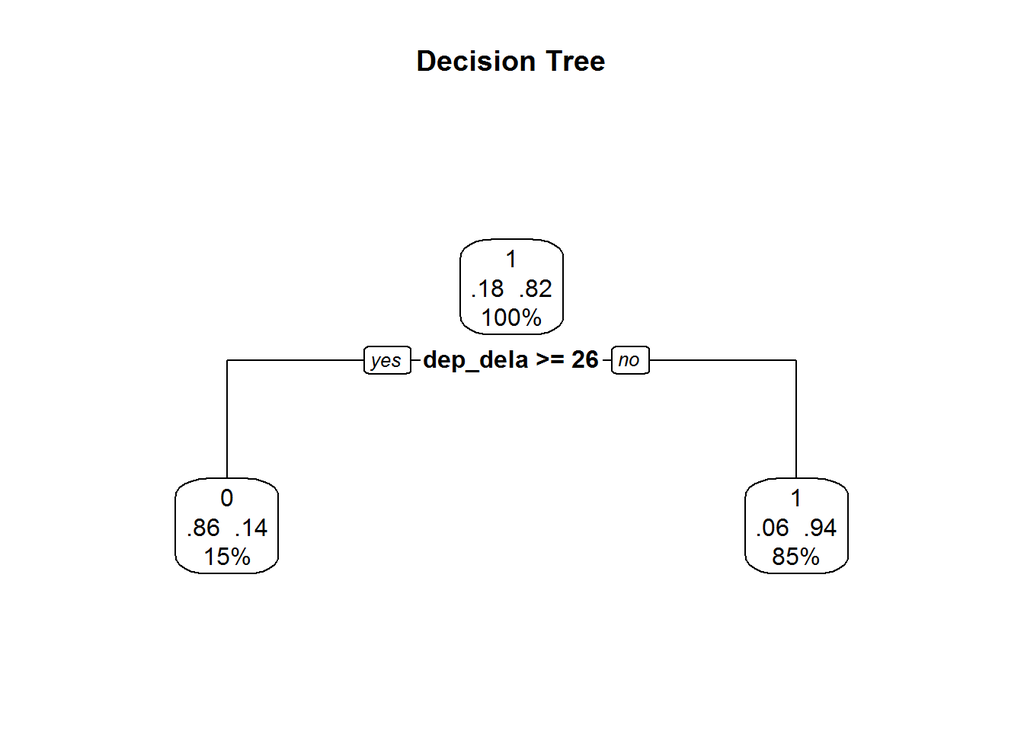

```r
prp(dtree3, type = 2, extra = 104,
    fallen.leaves = TRUE, main="Decision Tree")
```

#### Discussion of Model

- Discuss the difference between the models and why you would use one model over the other? Decision trees can at times overfit the data, but that isn’t an issue here. The decision tree model is much simpler than the logistic model as it only splits the data by the departure delay (over/under 25 minutes). On the other hand, the logistic model uses a dozen variables to predict the outcome. However, when comparing the diagnostics between the two models, such as: accuracy, kappa, sensitivity and specificity, the logistic model appears to be superior.
- How might you produce an ROC type curve for the *rpart* model? In this case, the ROC curve could be produced by changing the cutoff of the departure delay. This would be similar to changing the threshold used in the logistic model, but we would instead move the minutes of the departure delay either up or down and assess the sensitivity/specificity tradeoff.